# Asparagopsis parameteristation

Author

Tormey Reimer

Modified

5 August 2026

**All the code in this markdown is set to ‘fold’ by default. Click each folded code chunk to see its inner workings.**

```r
# You did it!
```

# Introduction

**Some global defaults I like to use**

```r
out_path <- here() %>% file.path("data")

prettyplot <- theme_classic() +
  theme(element_text(family = "sans", size = 12, colour = "black"),
        axis.title.y = element_text(vjust = 2),
        legend.position = "none")

format_sci2 <- function(x) {
  if (inherits(x, "units")) {format_sci(drop_units(x))} else {format_sci(x)}
}

remove_unit("gDW")
install_unit("gDW")
remove_unit("gFW")
install_unit("gFW")
remove_unit("photons")
install_unit("photons")

# This allows me to convert between moles and g of nitrogen
remove_unit("gN")
install_unit("gN")
remove_unit("molN")
install_unit("molN", "14.0067 gN")

S_uM <- set_units(seq(0, 200, 0.5), "umolN L-1")
S_mg <- set_units(S_uM, "mgN m-3")
```

The *Asparagopsis* genus (and especially *A. armata*) is invasive in the northeastern Atlantic and the Mediterranean (Zanolla et al. 2022). It has been studied more as an invasive genus than a native one. There are two species (or species complexes) within the genus *Asparagopsis*: *A. armata* is a temperate species while *A. taxiformis* is more commonly found in tropical areas (including northern Australia), and this might affect the results of the modelling - I may need to parameterise two different species, possibly distinct only in their temperature/light tolerance.

Phylogenetic analyses suggest that there is a clade within the species *A. armata* restricted only to Western Australia, Tasmania and New Zealand (Dijoux et al. 2014). It has been proposed that the species *A. armata* is actually two cryptic species: *A. armata* 1 is native to Tasmania and is invasive in the northern hemisphere, while *A. armata* 2 is restricted to Western Australia, Tasmania and New Zealand (Dijoux et al. 2014; Zanolla et al. 2022). Therefore, while the *A. armata* studied as an invasive species (*A. armata* 1) is partially representative of the Australian species, the lack of sampling in Australia and New Zealand may be leaving knowledge gaps of the potentially more widespread *A. armata* 2. It’s not known how much will this affect environmental growth responses in a model, given that the genus is very plastic in its environmental tolerance (Zanolla et al. 2022).

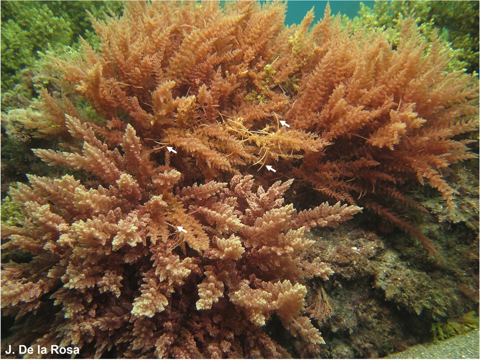

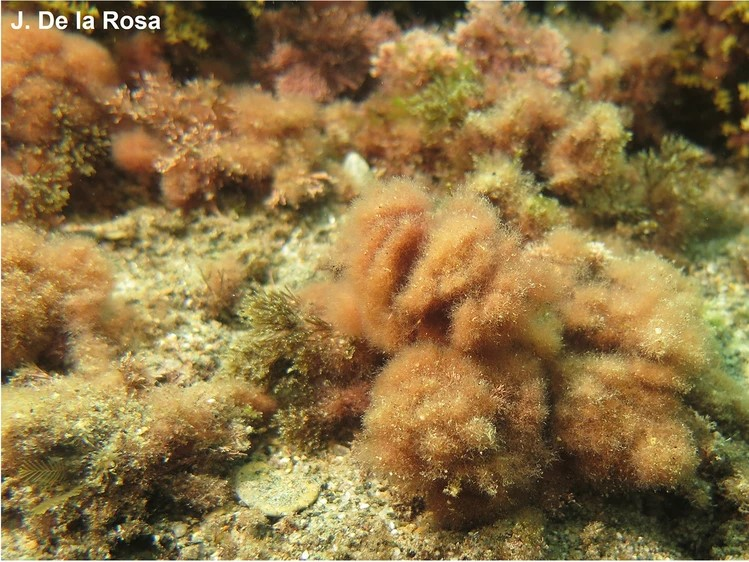

Figure 1: Left: Gametophytes of *Asparagopsis armata* (above) and *A. taxiformis* (below) at 5 m depth. Arrows point to harpoon-like branches in *A. armata*. Right: Tetrasporophyte of *Asparagopsis* at 3-m depth, presenting pompom structure and attached to other algae. Collected from Granada, Spain. Photo credits: J. De la Rosa, reproduced from Zanolla et al. (2022).

The different forms may also be very physiologically different in some respects - at the very least with regard to temperature and daylength. Catriona Hurd also thinks it’s likely they’ll be different in their uptake rates of the different forms of nitrogen.

## Still to investigate

- Cole et al. (2014)
- Dishon et al. (2023)
- Kraan and Barrington (2005)
- Mata (2008)
- Monro (2007)
- Torres et al. (2024)
- Wiltshire et al. (2015)
- Zanolla et al. (2019)

# Nitrogen uptake

## Linear uptake

It’s possible that the gametophyte and tetrasporophyte will have different uptake rates of ammonium and nitrate, and in the wild they do not appear to be affected by fluctuations in nutrients Zanolla, Altamirano, Carmona, et al. (2018). However, if we assume that the gametophyte has a similar preference for ammonium to the sporophyte then it’s not surprising that it would show little response to nutrients in the environment, as natural nitrogen is mostly in nitrate form with ammonium only being present at constant low levels generally.

**Important**

Zanolla, Altamirano, Carmona, et al. (2018) didn’t directly measure nutrients(?) but found that temperature was highly correlated with species distribution. Check Zanolla, Carmona, et al. (2018) - did they measure nutrients?

As far as I can tell, no-one has investigated nitrogen uptake directly in *Asparagopsis* gametophytes. I will therefore be using the uptake rates calculated for the tetrasporophyte.

Some very interesting things from reading Torres et al. (2021):

- Asparagopsis prefers ammonium during the internally-controlled (non-surge) phase
- Nitrate also taken up, but not preferred - even when nitrate was the only form available uptake was limited (limited use by seaweed)
- Amino acids (a mix of several different ones, with alanine dominating) were also tested. Amino acids are released by decomposing fish food. I may need to include amino acids as “other N” in the model.

Torres et al. (2021) tested the surge and internally-controlled nitrogen uptake rates of *A. armata* when given nitrogen in the form of ammonium, nitrate and a mix of amino acids (dominated by alanine). Nitrogen uptake (in all three forms) did not saturate at ~200 $\mu$M concentration, so was was better described with a linear equation rather than with Michaelis-Menton uptake kinetics

**Import Torres et al. (2021) data**

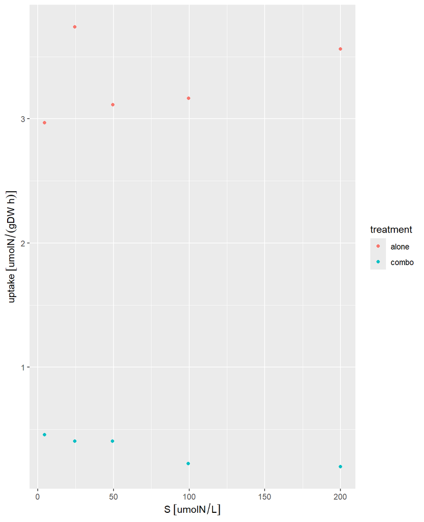

```r
remove_unit("molN") # Torres 2021 only used N-15 so need to readjust the units for this data
install_unit("molN", "15 gN")

torresNO3 <- read.csv(file.path("data_raw", "sources", "torres_2021", "tores-2021-Fig2-B.csv")) %>%
  mutate(uptake = uptake %>% set_units("umolN gDW-1 h-1"),
         S = S %>% set_units("umolN L-1"))

ggplot(torresNO3, aes(x = S, y = uptake, colour = treatment)) +
  geom_point()
```

**Import Torres et al. (2021) data**

```r
lm <- lm(uptake ~ S, data = filter(torresNO3, treatment == "alone"))
C_ni_alone <- coef(lm)["(Intercept)"] %>% unname() %>% set_units("umolN gDW-1 h-1")
M_ni_alone <- coef(lm)["S"] %>% unname() %>% set_units("L h-1 gDW-1")

lm <- lm(uptake ~ S, data = filter(torresNO3, treatment != "alone"))
C_ni_combo <- coef(lm)["(Intercept)"] %>% unname() %>% set_units("umolN gDW-1 h-1")
M_ni_combo <- coef(lm)["S"] %>% unname() %>% set_units("L h-1 gDW-1")
```

**Calculate uptake rates from Torres 2021 data**

```r
# From Torres et. al. 2021, Table 3
M_am_alone <- set_units(0.12, "L h-1 gDW-1")
C_am_alone <- set_units(10.45, "umolN h-1 gDW-1")

M_am_combo <- set_units(0.14, "L h-1 gDW-1")
C_am_combo <- set_units(8.79, "umolN h-1 gDW-1 ")

M_aa_alone <- set_units(0.007, "L h-1 gDW-1")
C_aa_alone <- set_units(1.69, "umolN h-1 gDW-1 ")

M_aa_combo <- set_units(0.006, "L h-1 gDW-1")
C_aa_combo <- set_units(0.88, "umolN h-1 gDW-1")

torres_uptake <- as.data.frame(S_uM) %>%
  mutate(ammonium_alone = lin_uptake(S_uM, M_am_alone, C_am_alone),
         ammonium_combo = lin_uptake(S_uM, M_am_combo, C_am_combo),
         nitrate_alone = lin_uptake(S_uM, M_ni_alone, C_ni_alone),
         nitrate_combo = lin_uptake(S_uM, M_ni_combo, C_ni_combo),
         nitrate_alone = lin_uptake(S_uM, M_ni_alone, C_ni_alone),
         nitrate_combo = lin_uptake(S_uM, M_ni_combo, C_ni_combo),
         amacids_alone = lin_uptake(S_uM, M_aa_alone, C_aa_alone),
         amacids_combo = lin_uptake(S_uM, M_aa_combo, C_aa_combo)) %>%
  pivot_longer(cols = !contains("S_uM"),
               names_to = c("form", "treatment"), names_sep = "_",
               values_to = "uptake",
               names_transform = list(form = as.factor, treatment = as.factor)) %>%
  mutate(S = set_units(S_uM, "mgN m-3"),
         uptake = set_units(uptake, "mgN gDW-1 d-1"))
```

Ammonium is obviously the preferred form of nitrogen uptake in *A. armata*. Amino acids and nitrate are taken up at approximately the same rate.

**Plot N uptake based on Torres et al. (2021) data**

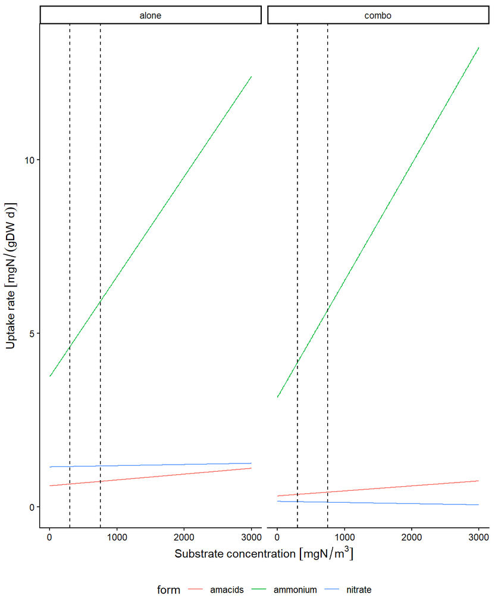

Linear uptake of ammonium (green), nitrate (blue) and amino acids (red) by *A. armata*. Dashed black lines show concentrations of 20 $\mu$M and 50 $\mu$M for reference.

```r
int1 <- 20 %>% set_units("umolN L-1") %>% set_units("mgN m-3")
int2 <- 50 %>% set_units("umolN L-1") %>% set_units("mgN m-3")

ggplot(torres_uptake, aes(x = S, y = uptake, colour = form)) +
  geom_line() +
  facet_wrap(vars(treatment)) +
  geom_vline(aes(xintercept = int1), linetype = "dashed") +
  geom_vline(aes(xintercept = int2), linetype = "dashed") +
  labs(y = "Uptake rate", x = "Substrate concentration") +
  prettyplot + theme(legend.position = "bottom")
```

```r
remove_unit("molN")
install_unit("molN", "15 gN")
```

## Michaelis–Menten uptake

Schuenhoff et al. (2006) fit a Michaelis–Menten curve to their uptake rates. They measured day and night uptake rates separately and combined. Their night and combined measurements were fairly poorly described by a Michaelis–Menten curve (R = 0.189 and 0.21 respectively) but daytime uptake was better (R$^2$ = 0.78). Since the model doesn’t have a day-night cycle anyway, I’ll be looking at the daytime parameters only.

**Plot curves based on Schuenhoff et al. (2006) data**

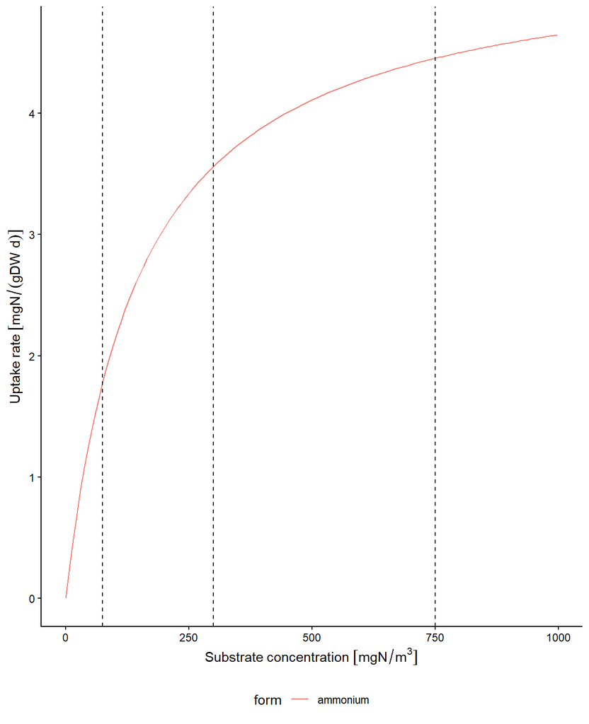

Michaelis–Menten uptake of ammonium by *A. armata*. Dashed black lines show concentrations of 5 $\mu$M, 20 $\mu$M and 50 $\mu$M for reference.

```r
V_am <- 14.85 %>% set_units("umolN gDW-1 h-1")
K_am <- 10.01 %>% set_units("umolN L-1")

schuen_uptake <- data.frame(S = S_uM) %>%
  mutate(uptake = MM_uptake(conc = S_uM, V = V_am, K = K_am),
         S = set_units(S_uM, "mgN m-3"),
         uptake = set_units(uptake, "mgN gDW-1 d-1"),
         form = factor("ammonium", levels = levels(torres_uptake$form)))

int1 <- 5 %>% set_units("umolN L-1") %>% set_units("mgN m-3")
int2 <- 20 %>% set_units("umolN L-1") %>% set_units("mgN m-3")
int3 <- 50 %>% set_units("umolN L-1") %>% set_units("mgN m-3")

schuen_uptake %>%
  filter(S <= set_units(1000, "mgN m-3")) %>%
  ggplot(aes(x = S, y = uptake, colour = form)) +
  geom_line() +
  geom_vline(aes(xintercept = int1), linetype = "dashed") +
  geom_vline(aes(xintercept = int2), linetype = "dashed") +
  geom_vline(aes(xintercept = int3), linetype = "dashed") +
  labs(y = "Uptake rate", x = "Substrate concentration") +
  theme_classic() + theme(legend.position = "bottom")
```

It’s immediately obvious that even though ammonium uptake by MM kinetics increases quickly at low concentrations, the linear uptake rate calculated by Torres et al. (2021) is higher than the MM uptake rate calculated by Schuenhoff et al. (2006), especially at low (5 $\mu$M) and very high (50 $\mu$M) concentrations.

**Compare Michaelis–Menten uptake with linear uptake of ammonium**

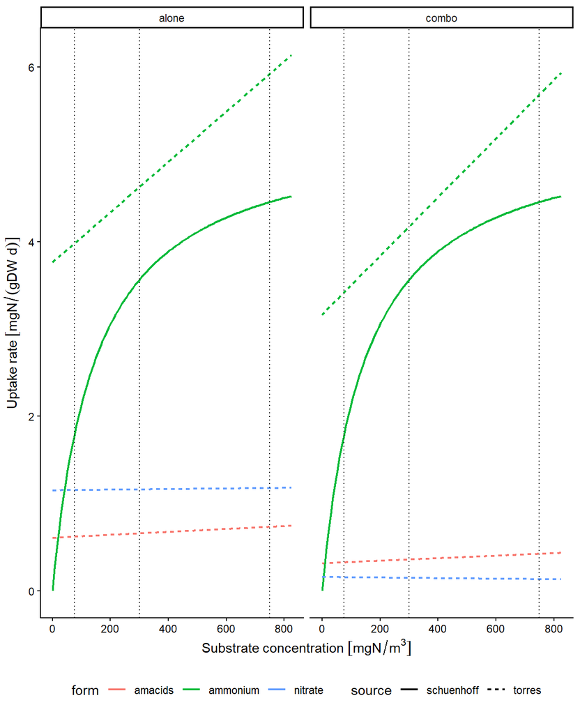

```r
both_uptake <- merge(torres_uptake, schuen_uptake, by = c("S", "form"), all = T) %>%
  rename(torres = uptake.x, schuenhoff = uptake.y) %>%
  pivot_longer(names_to = "source", values_to = "uptake", cols = c(torres, schuenhoff),
               names_transform = list(source = as.factor))

both_uptake %>%
  filter(S_uM <= set_units(55, "umolN L-1")) %>%
  ggplot(aes(x = S, y = uptake, color = form, linetype = source)) +
  geom_line(linewidth = 0.75) +
  facet_wrap(vars(treatment)) +
  geom_vline(aes(xintercept = int1), linetype = "dotted") +
  geom_vline(aes(xintercept = int2), linetype = "dotted") +
  geom_vline(aes(xintercept = int3), linetype = "dotted") +
  labs(y = "Uptake rate", x = "Substrate concentration") +
  prettyplot + theme(legend.position = "bottom")
```

**Choose which params of those investigated will make it into the model**

```r
# Note that even through MM uptake and linear uptake of ammonium are making it into the model, only one uptake shape can be used per nitrogen form at a time and this is specified in the model run.

# Note that even through MM uptake and linear uptake of ammonium are making it into the model, only one uptake shape can be used per nitrogen form at a time and this is specified in the model run.

V_am <- V_am # From Schuenhoff
K_am <- K_am # From Schuenhoff

M_am <- M_am_combo # From Torres
C_am <- C_am_combo # From Torres

M_ni <- M_ni_combo # From Torres (constant uptake)
M_ni <- M_ni_combo # From Torres (constant uptake)
C_ni <- C_ni_combo # From Torres

M_ot <- M_aa_combo # From Torres
C_ot <- C_aa_combo # From Torres
C_ot <- C_aa_combo # From Torres
```

# Internal nutrient state

## Tissue nitrogen concentration

The model requires minimum and maximum internal nitrogen concentrations. There are a couple of ways to go about estimating these:

- Take the lowest and highest N-concentrations I can find in the literature
- Take the lowest and highest protein concentrations I can find in the literature, and convert these into nitrogen. Protein estimates are much easier to find than N-concentration estimates, but the conversion to nitrogen adds uncertainty.

### Direct search

Mata et al. (2010) reported that *A. armata*’s N-content was 6.04% of DW at harvesting in December, up from 5.90% at the time of stocking (or 5.56% up to 5.62% in May).

**Clean up data from Mata et al. (2010)**

```r
# Data from Figure 1
mata_data_Y <- read.csv(file.path("data_raw", "sources", "mata_2010", "figure_1.csv")) %>%
  rename(biomass_yield = `Biomass.yield.gDW.m.2.d.1`,
         TAN_flux = `Weekly.average.TAN.flux.umol.L.1.h.1`) %>%
  mutate(biomass_yield = biomass_yield %>% set_units("gDW m-2 d-1"),
         TAN_flux = TAN_flux %>% set_units("umolN L-1 h-1"),
         species = as.factor(species),
         month = as.factor(month))

# Data from Figure 2
mata_data_N <- read.csv(file.path("data_raw", "sources", "mata_2010", "figure_2.csv")) %>%
  rename(biofiltration = `Biofiltration..g.N.m.2.d.1.`,
         TAN_flux = `Weekly.average.TAN.flux.umol.L.1.h.1`) %>%
  mutate(biofiltration = biofiltration %>% set_units("gN m-2 d-1"),
         TAN_flux = TAN_flux %>% set_units("umolN L-1 h-1"),
         measure = as.factor(measure),
         species = as.factor(species),
         month = as.factor(month)) %>%
  pivot_wider(names_from = measure, values_from = biofiltration)

# Plot data just to check it matches Mata 2010 - it does
# ggplot(data = filter(mata_data_Y, species == "A. armata"),
#        aes(x = TAN_flux, y = biomass_yield, colour = month)) +
#   geom_point()
# ggplot(data = filter(mata_data_N, species == "A. armata"),
#        aes(x = TAN_flux, y = N_yield, colour = month)) +
#   geom_point()
```

**Create curves from Mata et al. (2010) parameters**

```r
# Parameters from Figure 1 (May)
biom_Y_Vmax <- 153.6 %>% set_units("gDW m-2 d-1") # this is per m2 of a tank with SA=0.23m2
biom_Y_Ks <- 48.4 %>% set_units("umolN L-1 h-1")
biom_Y <- data.frame(flux = seq(0, 2000)) %>%
  mutate(flux = flux %>% set_units("umolN L-1 h-1"),
         biom_yield = MM_uptake(flux, V = biom_Y_Vmax, K = biom_Y_Ks))

# Parameters from Figure 2 (May, N-yield)
N_Y_Vmax <- 9.5 %>% set_units("gDW m-2 d-1")
N_Y_Ks <- 60.3 %>% set_units("umolN L-1 h-1")
N_Y <- data.frame(flux = seq(0, 200)) %>%
  mutate(flux = flux %>% set_units("umolN L-1 h-1"),
         N_yield = MM_uptake(flux, V = N_Y_Vmax, K = N_Y_Ks))

# Plot data just to check it matches Mata 2010 - it does
# ggplot(data = N_Y, aes(x = flux, y = N_yield)) +
#   geom_line() + prettyplot
# ggplot(data = biom_Y, aes(x = flux, y = biom_yield)) +
#   geom_line() + prettyplot

N_biom <- merge(biom_Y, N_Y, by = "flux") %>%
  mutate(N_biom = N_yield/biom_yield)

# ggplot(N_biom, aes(x = biom_yield, y = N_biom)) +
#   geom_point()

max_N_biom <- max(N_biom$N_biom, na.rm = T)
min_N_biom <- min(N_biom$N_biom, na.rm = T)
```

### Protein conversion

Maximum (or, at least, very high) internal nitrogen concentrations for *Asparagopsis* are fairly easy to find. *A. taxiformis* had a protein content of 22.69 %DM in Nunes et al. (2024) and 23.76 %DM in Pacheco et al. (2020). Nunes et al. (2024) also found that *A. armata* had a protein concentration of 24.23 %DM. However, the *A. taxiformis* spp. gametophytes eaten in Hawaii have also been reported having protein concentrations <10 %DW (McDermid and Stuercke 2003), and all of these measurements came from the invasive range of *Asparagopsis*.

Samples of *A. armata* collected from New Zealand showed a protein concentrations ranging from of 10.94 to 15.2 %DW (Mihaila et al. 2022; Zemke-White and Clements 1999), while Australian samples of *A. taxiformis* had mean a protein concentration of 18.2 %DW (Brooke et al. 2020).

**Range of protein concentrations**

```r
P_range_taxi <- sort(c(22.69, 23.76, 18.2, 7.5)) # Asparagopsis taxiformis
P_range_arma <- sort(c(24.23, 15.2, 10.94)) # Asparagopsis armata

N_conv_aspara <- 5.63
N_range_taxi_aspara <- P_range_taxi/N_conv_aspara # Asparagopsis taxiformis
N_range_arma_aspara <- P_range_arma/N_conv_aspara # Asparagopsis armata

N_conv_reds <- 5.1
N_range_taxi_reds <- P_range_taxi/N_conv_reds # Asparagopsis taxiformis
N_range_arma_reds <- P_range_arma/N_conv_reds # Asparagopsis armata
```

There are also different possible ways of converting protein to nitrogen: Angell et al. (2016) suggested that a factor 5.1 is most appropriate for red algae, although they also reported *Asparagopsis* specifically having a conversion factor of 5.63 which was used by Mihaila et al. (2022) in their calculations. The results of these conversions are summarised in Table 1.

Table 1: Observed protein concentrations in *Asparagopsis* species

[output not shown]

**Choose which params of those investigated will make it into the model**

```r
N_min <- set_units(min(P_range_arma/100)/N_conv_aspara, "gN gDW-1")
Q_min <- set_units(N_min, "mgN gDW-1")
N_min <- set_units(min(P_range_arma/100)/N_conv_aspara, "gN gDW-1")
Q_min <- set_units(N_min, "mgN gDW-1")
N_max <- set_units(0.065, "gN gDW-1") # Schuenhoff 2006
Q_max <- set_units(N_max, "mgN gDW-1")
Q_max <- set_units(N_max, "mgN gDW-1")
```

# Biomass factors

## Dry weight to fresh weight

- Schuenhoff et al. (2006) found that the DW:FW ratio of *A. armata* remained constant at 0.25 $\pm$ 0.001 (mean $\pm$ SD) regardless of season or stocking density (tetrasporophytes sourced from southern Portugal, tank-grown in fish farm effluent at a water exchange rate of 2 Vol hr$^{-1}$).
- Sainz-Villegas et al. (2024) measured the change from FW to DW as 0.12.
- Nunes et al. (2024) found a dry mass of 6.55 $\pm$ 1.25% for *A. taxiformis* gametophytes and 7.68 $\pm$ 1.07% for *A. armata* gametophytes, and reported that similar values were found by Roque et al. (2019).

**Summarise possible DWWW values**

```r
# schuenhoff_tetrasporophyte_2006
remove_unit("gWW")
install_unit("gWW", "0.25 gDW")
DWWW_schuen <- set_units(1, "gDW") %>% set_units("gWW")

# sainz-villegas_exploring_2024
remove_unit("gWW")
install_unit("gWW", "0.12 gDW")
DWWW_sainz <- set_units(1, "gDW") %>% set_units("gWW")

# nunes_evaluation_2024/roque_effect_2019
remove_unit("gWW")
install_unit("gWW", "0.1302083 gDW") # 1/7.68
DWWW_nunes_arma <- set_units(1, "gDW") %>% set_units("gWW")
remove_unit("gWW")
install_unit("gWW", "0.1526718 gDW") # 1/6.55
DWWW_nunes_taxi <- set_units(1, "gDW") %>% set_units("gWW")
```

These options give DW:WW values of 4, 8.33, or 7.68 for *A. armata* and 6.55 (*A. taxiformis*). However, only Nunes et al. (2024) specifically looked at the gametophyte.

**Choose which params of those investigated will make it into the model**

```r
DWWW <- mean(c(DWWW_nunes_arma, DWWW_nunes_taxi))
DWWW <- mean(c(DWWW_nunes_arma, DWWW_nunes_taxi))
```

## Height

Within the model, “height” does not indicate height exactly, rather it indicates how much of the available space is being taken up by the macroalgae. This combines with density (mg m$^{-3}$, i.e. growth) to indicate how much light and nutrients the macroalgae has access to. For example:

- a macroalgae with a high growth rate but a low height-increase rate (e.g. an *Asparagopsis* tetrasporophyte) will be more dense in a smaller volume, potentially having higher self-shading rates and decreased access to nutrients
- a macroalgae with a low growth rate and a high height-increase rate (e.g. *Ecklonia*) will be less dense in a larger volume, potentially lower self-shading rates and increased access to nutrients

Zanolla, Altamirano, De La Rosa, et al. (2018) reported that *A, taxiformis* gametophyte branches had a maximum length of ~26 cm at ~115 g DW m$^{-2}$.

**Height stats from Zanolla, Altamirano, De La Rosa, et al. (2018)**

```r
sizedis <- set_units(115,"gDW m-2")*set_units(0.26,"m-1")
sizedisN <- set_units(drop_units(sizedis*0.06), "g m-3")
sizedisN <- set_units(sizedisN, "mg m-3")

sizedis2 <- set_units(115,"gDW m-2")*set_units(0.26,"m-1")
sizedisN2 <- set_units(drop_units(sizedis2*0.06), "g m-3")
sizedisN2 <- set_units(sizedisN2, "mg m-3")/10
```

**Create a realistic height curve**

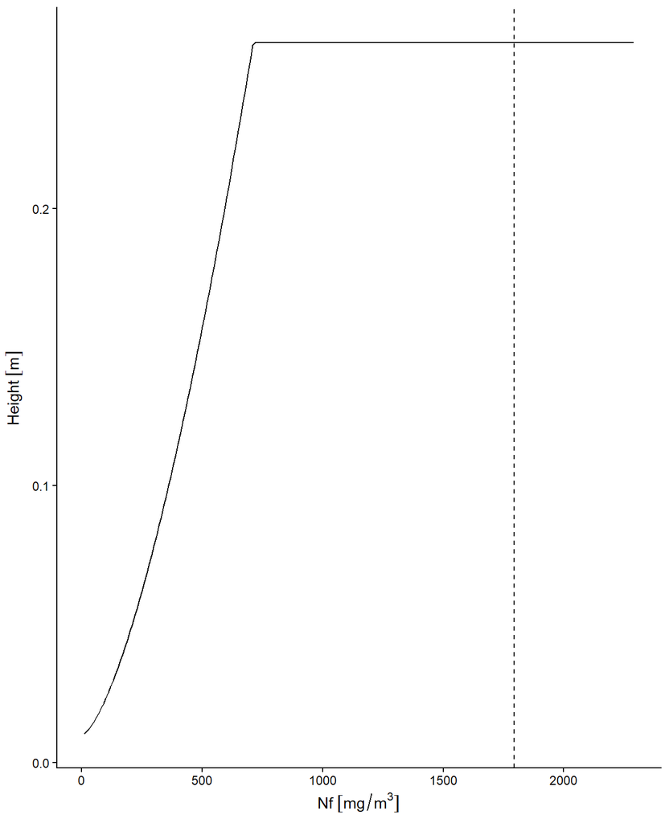

```r
h_a <- drop_units(sizedisN)
h_b <- 1.5
h_c <- 0.01
h_max <- 0.26 %>% set_units("m")
h_max <- 0.26 %>% set_units("m")

dens <- seq(10, drop_units(sizedisN)+500, 10)
h <- sapply(X = dens, FUN = height, spec_params = c(h_a = h_a, h_b = h_b, h_c = h_c, h_max = drop_units(h_max)))
height <- data.frame(dens = set_units(dens, "mg m-3"), h = set_units(h, "m"))

ggplot(height) +
  geom_line(aes(x = dens, y = h)) +
  geom_vline(xintercept = sizedisN, linetype = "dashed") +
  prettyplot +
  labs(x = "Nf", y = "Height")
```

## Growth rate & stocking density

Zanolla, Altamirano, De La Rosa, et al. (2018)? Wright et al. (2022)?

Schuenhoff et al. (2006) investigated the optimal stocking density for *A. armata* in spring and winter at a high water exchange rate (2 Vol hr$^{-1}$). Yield was determined via:

$$Y(g DW m^{−2} week^{−1}) = \frac{N_t (g FW) − N_0 (g FW)}{t (weeks) \times DW:FW \times Area (m^{2})}$$

The area of each tank was 0.23 m$^{-2}$ (with a depth of 0.48 m).

Maximum yields in Schuenhoff et al. (2006) in both seasons was achieved at a stocking density of 5 g FW l$^{-1}$, but the yield in spring was higher than in winter (~700 vs ~520 g DW m$^{-2}$ week$^{-1}$). These can be converted to mg N m$^{-2}$ d$^{-1}$:

**Get Schuenhoff et al. (2006) starting condition and yield data**

```r
# schuenhoff_tetrasporophyte_2006 dry to wet conversion
remove_unit("gWW")
install_unit("gWW", "0.25 gDW")

spring <- read.csv(file.path("data_raw", "sources", "schuenhoff_2006", "schuenhoff_2006_Fig1_spring-data.csv"), header = F) %>%
  mutate(season = "spring")
winter <- read.csv(file.path("data_raw", "sources", "schuenhoff_2006", "schuenhoff_2006_Fig1_winter-data.csv"), header = F) %>%
  mutate(season = "winter")

N_perc <- set_units(0.065, "gN gDW-1")
C_perc <- set_units(0.355, "gN gDW-1") # C:N ratio (or C% of tissue) is not currently used within the model but might be useful later

# initial starting value
stock_dens <- set_units(5, "gWW L-1") %>% set_units("gDW m-3")
stock_dens <- (stock_dens*N_perc) %>% set_units("mgN m-3")

yield_spring <- set_units(700, "gDW m-2 week-1")
yield_spring <- yield_spring/set_units(0.48, "m")
yield_spring <- set_units(yield_spring*N_perc, "mgN m-3 d-1")

yield_winter <- set_units(520, "gDW m-2 week-1")
yield_winter <- yield_winter/set_units(0.48, "m")
yield_winter <- set_units(yield_winter*N_perc, "mgN m-3 d-1")

max_growth <- c(spring = yield_spring/stock_dens, winter = yield_winter/stock_dens)
mu <- max(max_growth)
```

**Scale max growth with Q_lim**

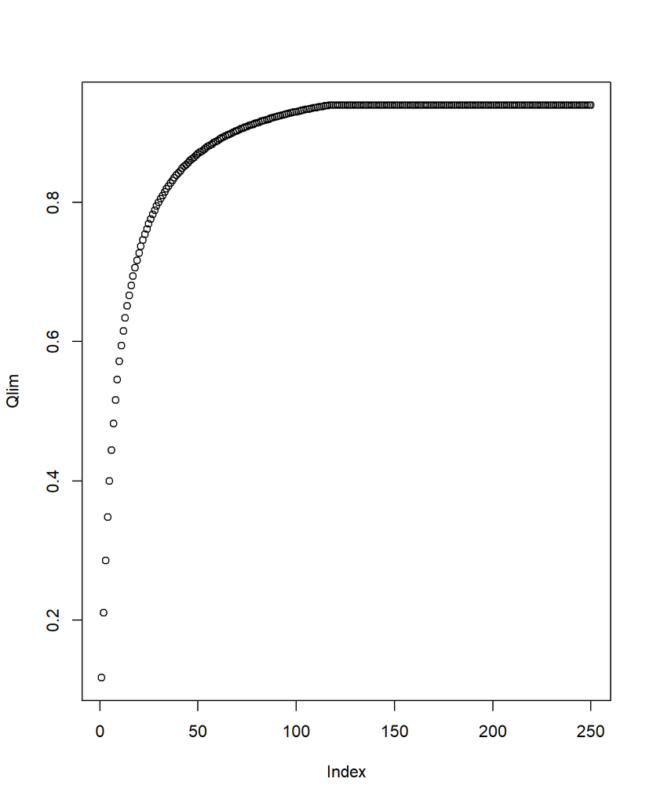

```r
Qlim <- sapply(
  X = 1:250,
  FUN = Q_lim,
  Nf = 50,
  spec_params = drop_units(c(Q_min = Q_min, Q_max = Q_max, K_c = Q_min * 0.85))
  )
plot(Qlim)
```

**Scale max growth with Q_lim**

```r
max(Qlim)
```

```
[1] 0.9398813
```

The maximum growth rate ($\mu$) for *A. armata* reported in Schuenhoff et al. (2006) was 16.67% in spring and 12.38% in winter. Hard to know if these are being limited by factors other than temperature/light, so I am going to use the maximum $=$16.6666666666667% for growth in all seasons.

# Salinity

Not much is known about how *Asparagopsis* responds to salinity, but it is thought to be fairly intolerant of low salinity (Camille White, pers. comm.). Mean salinity in most Tasmanian coastal waters is fairly consistent at ~35.25 PSU, so I’m going to set that as the optimum for both species.

**Estimate salinity parameters**

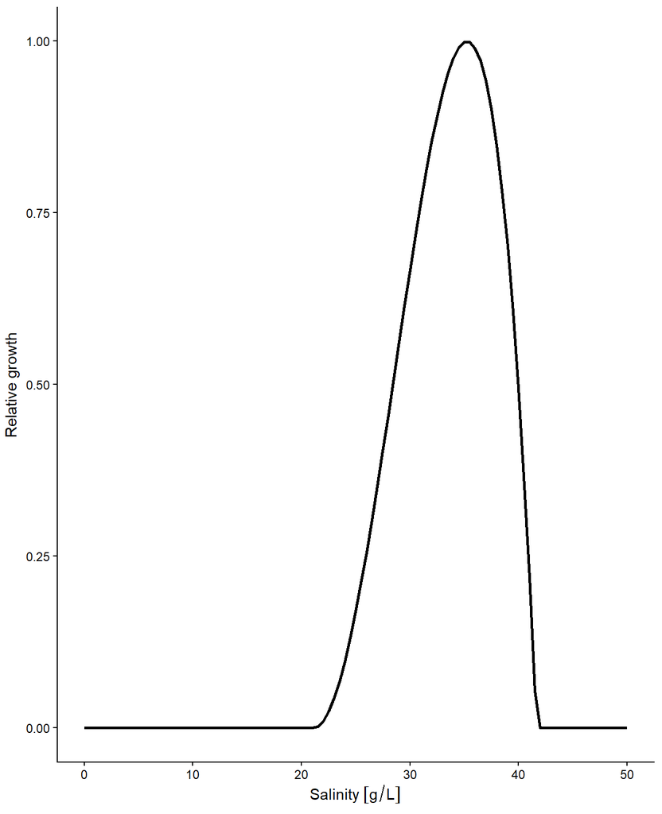

```r
S_opt <- set_units(35.25, "g L-1")
S_min <- set_units(21.15, "g L-1")  # ecklonia minimum is 80% of mean below mean. This is 40% of mean below mean.
S_max <- set_units(41.65, "g L-1")  # ecklonia minimum is 36% of mean below mean. This is 18% of mean below mean.
sal <- seq(0,50,0.5) %>% set_units("g L-1")
Slim <- sapply(X = sal, FUN = T_lim, spec_params = c(T_opt = S_opt, T_min = S_min, T_max = S_max))

ggplot(mapping = aes(x = sal, y = Slim)) +
  geom_line(size = 1) +
  theme_classic() +
  theme(legend.position = "none", element_text(family = "sans", colour = "black", size = 11),
        axis.title.y = element_text(vjust = 2)) +
  labs(x = expression("Salinity"), y = "Relative growth")
```

# Temperature response

By default, the gametophyte temperature parameters for *Asparagopsis* in the model will be identical to the tetrasporophyte. This is because much less research has been done on the gametophyte phases. However, the gametophyte and tetrasporophyte phase might have similar temperature optima. In Chualáin et al. (2004) *A.taxiformis* tetrasporophytes had an optimum growth temperature of 25$^{\circ}$, and this same growth optimum was observed in *A.taxiformis* gametophytes by Padilla-Gamiño and Carpenter (2007).

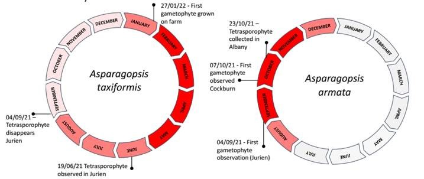

Figure 3: Timing of sea-cultured gametophytes and their appearance in the wild. Dark red indicates when the gametophyte is present on the reef, and lighter red indicates when gametophytes are just starting to appear or disappear, so less abundant. Tetrasporophytes have thus far been very difficult to find in the wild (Margie Rule, pers. comm.).

Previous studies on the temperature tolerance of *Asparagopsis* tetrasporophytes were reviewed by Zanolla et al. (2022), and Chualáin et al. (2004) collated previous studies’ observations on growth minima and maxima. They found that *A. armata* had a minimum growth temperature of 5-7$^\circ$, an optimum growth temperature of 15 or 20$^\circ$, and a maximum growth temperature of 25$^\circ$C. However, it should be noted that within Chualáin et al. (2004) the only sample collected from Australia (Sorrento Back Beach, Victoria, from the lower eulittoral zone) had an optimum growth temperature of 15$^\circ$C.

**Get temperature/irradiance data from Zanolla et al. (2015), Figure 1**

```r
zanolla1 <- list(read.csv(file.path("data_raw", "sources", "zanolla_2015", "12 degrees.csv"), header = F) %>% mutate(temp = 12),
                 read.csv(file.path("data_raw", "sources", "zanolla_2015", "15 degrees.csv"), header = F) %>% mutate(temp = 15),
                 read.csv(file.path("data_raw", "sources", "zanolla_2015", "18 degrees.csv"), header = F) %>% mutate(temp = 18),
                 read.csv(file.path("data_raw", "sources", "zanolla_2015", "22 degrees.csv"), header = F) %>% mutate(temp = 22),
                 read.csv(file.path("data_raw", "sources", "zanolla_2015", "26 degrees.csv"), header = F) %>% mutate(temp = 26))

zanolla1 <- bind_rows(zanolla1)
colnames(zanolla1) <- c("Irradiance", "NPR", "Temperature")
zanolla1$NPR_rel <- zanolla1$NPR/max(zanolla1$NPR)

# # For when I need units
# zanolla1$Irradiance <- set_units(zanolla1$Irradiance, "umol m-2 s-1")
# zanolla1$NPR <- set_units(zanolla1$NPR, "mg gWW-1 h-1")
# zanolla1$Temperature <- set_units(zanolla1$Temperature, "C")
```

**Get temperature/irradiance data from Zanolla et al. (2015)**

```r
zanolla1 <- zanolla1 %>%
  mutate(Irr_group = case_when(
    Irradiance > 0 & Irradiance < 10 ~ "~5.7", Irradiance > 10 & Irradiance < 20 ~ "~19.8",
    Irradiance > 20 & Irradiance < 35 ~ "~32.3", Irradiance > 35 & Irradiance < 65 ~ "~55.3",
    Irradiance > 65 & Irradiance < 130 ~ "~124.1", Irradiance > 130 & Irradiance < 260 ~ "~254.4",
    Irradiance > 260 & Irradiance < 370 ~ "~365.9", Irradiance > 370 & Irradiance < 510 ~ "~504.5",
    Irradiance > 510 ~ "~598.5", TRUE ~ NA),
    Irr_group = factor(Irr_group,
                       levels = c("~5.7", "~19.8", "~32.3", "~55.3", "~124.1", "~254.4", "~365.9", "~504.5", "~598.5")))

pT.1 <- ggplot(dplyr::filter(zanolla1, Irradiance > 0),
       aes(x = Temperature, y = NPR_rel, color = Irr_group)) +
  geom_line() +
  theme_classic()
# pT.1
```

**Setting temperature params**

```r
both <- bind_rows(
  list(
    read.csv(file.path("data_raw", "sources", "chualain_2004", "armata.csv"), header = F) %>% mutate(species = "armata"),
    read.csv(file.path("data_raw", "sources", "chualain_2004", "taxiformis.csv"), header = F) %>% mutate(species = "taxiformis")
  )) %>%
  mutate(sample = V3,
         temperature = V2,
         variable = factor(V4, levels = c(" grow min", " grow max"), labels = c("grow_min", "grow_max"))) %>%
  group_by(species, variable) %>%
  reframe(temperature = mean(temperature))

T_max_arma <- both$temperature[both$species == "armata" & both$variable == "grow_max"] %>% set_units("degree_C")
T_min_arma <- both$temperature[both$species == "armata" & both$variable == "grow_min"] %>% set_units("degree_C")
T_max_taxi <- both$temperature[both$species == "taxiformis" & both$variable == "grow_max"] %>% set_units("degree_C")
T_min_taxi <- both$temperature[both$species == "taxiformis" & both$variable == "grow_min"] %>% set_units("degree_C")
T_opt_arma <- mean(c(20,20,15,15,20,20,20,20,20,20,20)) %>% set_units("degree_C")
T_opt_taxi <- mean(c(25,25,25,25,25,25,25,25,25,20,25,25,25)) %>% set_units("degree_C")
T_max_arma <- both$temperature[both$species == "armata" & both$variable == "grow_max"] %>% set_units("degree_C")
T_min_arma <- both$temperature[both$species == "armata" & both$variable == "grow_min"] %>% set_units("degree_C")
T_max_taxi <- both$temperature[both$species == "taxiformis" & both$variable == "grow_max"] %>% set_units("degree_C")
T_min_taxi <- both$temperature[both$species == "taxiformis" & both$variable == "grow_min"] %>% set_units("degree_C")
T_opt_arma <- mean(c(20,20,15,15,20,20,20,20,20,20,20)) %>% set_units("degree_C")
T_opt_taxi <- mean(c(25,25,25,25,25,25,25,25,25,20,25,25,25)) %>% set_units("degree_C")
```

**Add a $T_{lim}$ function to plot of temperature/irradiance data from Zanolla et al. (2015), Figure 1**

```r
test_T <- data.frame(Tc = seq(5, 28, 0.5))
test_params <- c(T_opt = T_opt_arma, T_max = T_max_arma, T_min = T_min_arma)
test_T$arma <- sapply(X = test_T$Tc, FUN = T_lim, spec_params = drop_units(test_params))
test_T$arma <- sapply(X = test_T$Tc, FUN = T_lim, spec_params = drop_units(test_params))
test_params <- c(T_opt = T_opt_taxi, T_max = T_max_taxi, T_min = T_min_taxi)
test_T$taxi <- sapply(X = test_T$Tc, FUN = T_lim, spec_params = drop_units(test_params))
test_T$taxi <- sapply(X = test_T$Tc, FUN = T_lim, spec_params = drop_units(test_params))

pT.2 <- pT.1 +
  geom_line(data = test_T, aes(x = Tc, y = arma), color = "black") +
  geom_line(data = test_T, aes(x = Tc, y = taxi), color = "black", linetype = "dashed")
# pT.2
```

It seems that *A. taxiformis* has a slightly higher optimum temperature than *A. armata* * The optimum temperature for *A. armata* in Zanolla et al. (2015) was ~22$^\circ$C, although they only tested 5 temperatures (12, 15, 18, 22, and 26$^\circ$C). * Sainz-Villegas et al. (2024) also only tested three temperatures (15, 20, and 25$^\circ$C). There was no positive growth at 25$^\circ$C regardless of irradiance and 20$^\circ$C showed mixed results. However, their irradiance was kept between 55-60 $\mu$mol photons m$^{-2}$ s$^{-1}$, which seems very low to me. * Mata et al. (2006) found that net growth was significantly decreased above 29$^\circ$C due to an increase in respiration * Mata et al. (2017) investigated temperature limits of *A. taxiformis*, but like Zanolla et al. (2015) they didn’t actually do a full temperature range experiment and only tested three temperatures. Still, growth was best at 20.2$^\circ$C.